# Análise exploratória da relação entre o PIB e os dados populacionais de um país

Pedro Guimarães Medeiros

## As duas bases de dados usadas

ㅤ ㅤ ㅤ ㅤ

Distribuição da expectativa de vida mundial

| Ano da pesquisa | Média | Mediana | Desvio padrão |
| --- | --- | --- | --- |
| 2010 | 74.9 | 75.3 | 6.1 |
| 2015 | 76.1 | 76.4 | 5.7 |
| 2020 | 75.9 | 76.0 | 5.7 |
| 2025 | 77.6 | 78.1 | 5.3 |

Dados obtidos no site da ONU

Distribuição da taxa de fertilidade mundial

| Ano da pesquisa | Média | Mediana | Desvio padrão |
| --- | --- | --- | --- |
| 2010 | 2.08 | 1.9 | 0.79 |
| 2015 | 2.00 | 1.8 | 0.71 |
| 2020 | 1.85 | 1.6 | 0.63 |
| 2025 | 1.74 | 1.5 | 0.60 |

Dados obtidos no site da ONU

. . . . ㅤ ㅤ

- A expectativa de vida aumenta em 2.7 anos;
- A taxa de fertilidade diminui em 0.34 filhos por mulher.

# Análise da taxa de fertilidade global nos anos de 2010, 2015, 2020 e 2025

[interactive chart not shown]

- A média da taxa de fertilidade global está caindo drasticamente a cada 5 anos;
- Os países mais ricos tem taxa de fertilidade muito menor aos demais, isso pode ser devido à maior acesso à métodos contraceptivos;
- A taxa de fertilidade em 2010 era igual ao nível de reposição, sendo 2.1;
- A taxa de fertilidade em 2025 era igual á 1.7, indicando diminuição na população mundial no futuro.

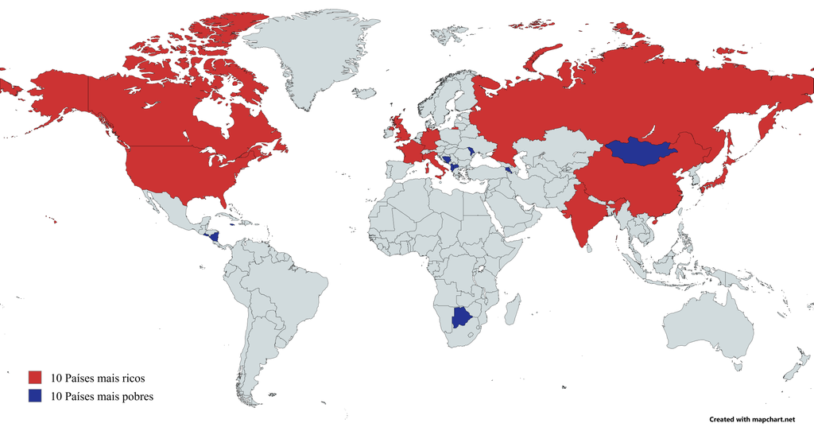

- Representação dos 10 países mais ricos e mais pobres no ano de 2025, que são os mesmos utilizados no gráfico anterior.
- Pode ser observado que os países mais ricos se concentram no hemisfério Norte.

# Comparação da expectativa de vida nos anos de 2010 e 2025 em países ricos, emergentes e pobres

[interactive chart not shown]

[interactive chart not shown]

- A mediana para os países mais ricos é de 82 anos, 2 a mais quando comparada com 2010;
- A maioria dos países tem sua expectativa de vida maior do que 77 anos.

## Fontes dos dados

- [Site do Banco Mundial](https://datacatalog.worldbank.org/search/dataset/0037798/global-economic-monitor) - Onde os dados do PIB foram adquiridos.
- [Site das Nações Unidas](https://data.un.org/) - Onde os dados da taxa de crescimento e a taxa de fertilidade foram adquiridos.
- [MapChart](https://www.mapchart.net/index.html) - Site usado para criar o mapa customizado que foi usado.
- Pacotes usados na computação e visualização dos dados utilizados:
1. [tidyverse](https://tidyverse.tidyverse.org/) - Junção de vários pacotes, sendo o mais usado nesse documento o `ggplot`, função para gerar gráficos.
2. [ggthemes](https://r-graph-gallery.com/package/ggthemes.html) - Complemento para adicionar temas em gráficos.
3. [plotly](https://plotly.com/r/) - Usado para transormar tabelas estáticas em interativas.
4. [gt](https://gt.rstudio.com/) - Usado para criar tabelas.